# Assignment 5

Berk Yılmaz

2024-10-10

# Assignment

Write all your text and R code in an R markdown file and compile an html file whose ZIP file can be handed in on Blackboard.

# 1. Non-negative matrix factorization

In this part of the assignment, non-negative matrix factorization (NMF) is used to once again learn the components which drive the stock market. Now, instead of the closing prices, the numbers of shares traded for 5 recent years for 505 companies currently found on the S&P 500 index, are used.

The data for this exercise can be found in the file: volume stocks.dat. The first feature in this data file is name and gives an abbreviation of the company name. The features named v1 to v1259 are the numbers of shares traded on 1259 days within 5 recent years.

Import the data into R. Be aware that the data file is tab-delimited and that the first line in the data file contains the feature names. The feature name (the first column) is not relevant for the analysis and should be removed. Certain companies have missing values. Remove the companies with missing values and only use the complete cases (companies). Next, store the data in a matrix.

Apply NMF to the data matrix. Determine the dimension using the proportion of explained variance.

```r
# Importing and tidying the dataset
data <- read.delim("volume_stocks.dat", header = TRUE)
cleaned_data <- na.omit(data)
data_matrix <- as.matrix(cleaned_data[ , -1])

# Checking that the values are non-negative, as this is a requirement in Non-Negative Matrix Factorization
data_matrix[data_matrix < 0] <- 0
```

## (a) How many dimensions do you select?

```r
library(NMF)
```

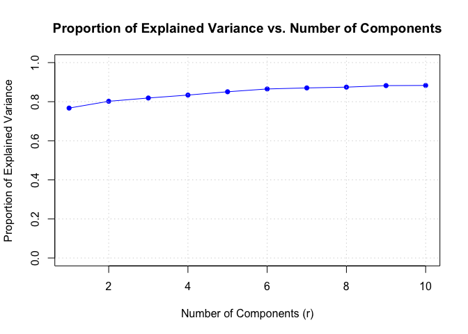

```r
# Apply Non-negative Matrix Factorization
# Set the rank (number of components)
rank_range <- 1:10
n <- length(rank_range)
explained_variance <- numeric(n)
proportion_explained_variance <- numeric(n)

# Calculate total variance of the original matrix
total_variance <- sum(data_matrix^2)

# Initialize a list to store reconstructed matrices
reconstructed_matrix <- vector("list", n)

for (i in rank_range) {
  nmf_result <- nmf(data_matrix, i)

  # Store the reconstructed matrix
  reconstructed_matrix[[i]] <- fitted(nmf_result)

  # Calculate variance of the reconstructed matrix (explained variance)
  explained_variance[i] <- sum(reconstructed_matrix[[i]]^2)

  # Calculate proportion of explained variance
  proportion_explained_variance[i] <- explained_variance[i] / total_variance
}

# Now we plot it
plot(rank_range, proportion_explained_variance, type = "o", pch = 16, lty = 1,
     col = "blue", main = "Proportion of Explained Variance vs. Number of Components",
     xlab = "Number of Components (r)", ylab = "Proportion of Explained Variance",
     ylim = c(0, 1))
grid()
```

To determine the number of dimensions, we can look at the rank set in Non-Negative Matrix Factorization:

```r
rank_selected <- 6
cat("Selected number of dimensions (rank):", rank_selected)
```

```
## Selected number of dimensions (rank): 6
```

## (b) Give the proportion of explained variance for this number of dimensions

```r
# Now we want to see the proportion of explained variance
cat("Proportion of explained variance:", proportion_explained_variance[rank_selected])
```

```
## Proportion of explained variance: 0.8650642
```

## (c) Give the reconstruction error for this number of dimensions

```r
# I will be looking at the reconstruction error
nmf_result_selected <- nmf(data_matrix, rank_selected)
reconstructed_matrix_selected <- fitted(nmf_result_selected)
reconstruction_error_selected <- sqrt(sum((data_matrix - reconstructed_matrix_selected)^2))
cat("Reconstruction error:", reconstruction_error_selected, "\n")
```

```
## Reconstruction error: 2662629768
```

## Calculate the correlation matrix of the finally selected dimensions

```r
# Now we are asked to find the correlation matrix
W <- basis(nmf_result_selected)
H <- coef(nmf_result_selected)
correlation_matrix_selected <- cor(W)
cat("Correlation matrix:", correlation_matrix_selected)
```

[output not shown]

## (e) Calculate the values of Hoyer’s sparseness coefficient for the features matrix and the coefficients matrix.

```r
# We will now define a function that will calculate the Hoyer's sparseness coefficient by using the formula
sparseness <- function(X) {
  n <- length(X)
  numerator <- sqrt(n) - sum(abs(X)) / sqrt(sum(X^2))
  denominator <- sqrt(n) - 1
  return(numerator / denominator)
}

W_sparseness <- sparseness(as.vector(W))
H_sparseness <- sparseness(as.vector(H))

cat("Hoyer's sparseness coefficient for W matrix:", W_sparseness, "\n")
```

```
## Hoyer's sparseness coefficient for W matrix: 0.655615
```

```r
cat("Hoyer's sparseness coefficient for H matrix:", H_sparseness, "\n")
```

```
## Hoyer's sparseness coefficient for H matrix: 0.2561068
```

## (f) Produce heat maps for the features matrix and the coefficients matrix

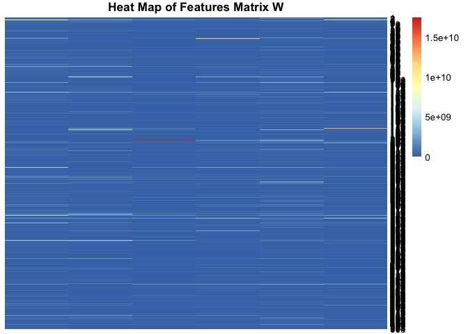

```r
library(pheatmap)

# Heat map for the features matrix W
pheatmap(W, main = "Heat Map of Features Matrix W", cluster_rows = FALSE, cluster_cols = FALSE)
```

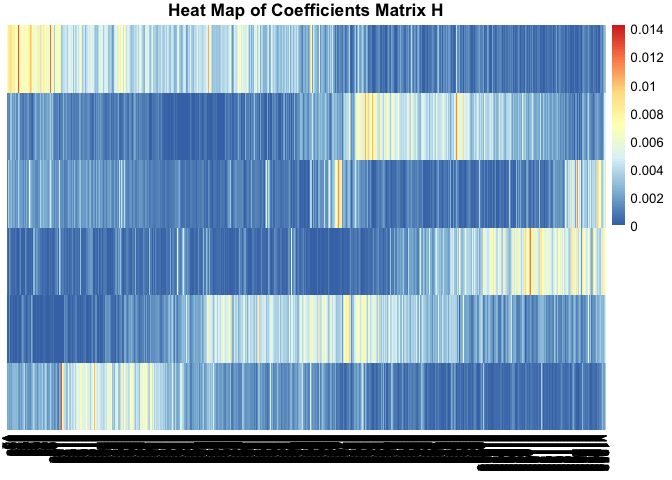

```r
# Heat map for the coefficients matrix H
pheatmap(H, main = "Heat Map of Coefficients Matrix H", cluster_rows = FALSE, cluster_cols = FALSE)
```

# 2. Probabilistic latent semantic analysis In this part of the assignment, probabilistic latent semantic analysis is applied to the data file benthos.txt. The data set consists of abundances of 10 marine species near an oilfield in the North Sea at 13 sites (the columns in the data file). The first 11 columns give the data for polluted sites. The last two columns give the data for unpolluted reference sites. Import the data into R and store the data as a matrix.

```r
# Importing and tidying of the data
library(topicmodels)
data_2 <- read.delim("benthos.txt", header = F)
data_matrix_2 <- as.matrix(data_2)

# Again, we check whether all values are non-negative, since it is a prerequisite
data_matrix_2[data_matrix_2 < 0] <- 0
```

Carry out a probabilistic latent semantic analysis. Use the proportion of explained variance to determine the number of latent classes.

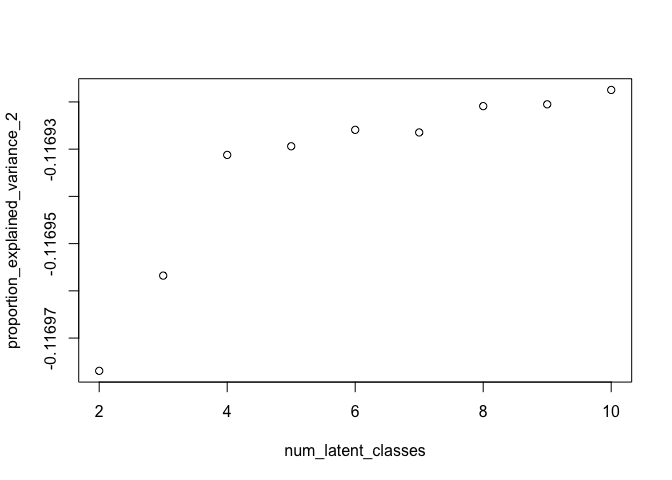

```r
num_latent_classes <- 2:10

n_2 <- length(num_latent_classes)
explained_variance_2 <- numeric(n_2)
proportion_explained_variance_2 <- numeric(n_2)

# Finding the total variance
  total_variance <- sum((data_matrix_2 - mean(data_matrix_2))^2)

for (i_2 in 1:n_2){
  plsa_model <- LDA(data_matrix_2, num_latent_classes[i_2])


  # Now I will reconstruct the matrix
  reconstructed_matrix <- posterior(plsa_model)$topics %*% posterior(plsa_model)$terms

  # Finding the residual variance
  residual_variance <- sum((data_matrix_2 - reconstructed_matrix)^2)

  explained_variance_2[i_2] <- total_variance - residual_variance

  # Now we find the proportion of the explained variance
  proportion_explained_variance_2[i_2] <- explained_variance_2[i_2] / total_variance
}

plot(num_latent_classes, proportion_explained_variance_2)
```

## (a) How many latent classes do you select? Why?

```r
# We select 4
optimal_latent_classes <- 4
cat("Number of latent classes selected:", optimal_latent_classes)
```

```
## Number of latent classes selected: 4
```

## (b) What is the proportion of variance explained for the number of latent classes selected?

```r
# The proportion of variance explained for 4 latent classes is
cat("The proportion of variance explained for 4 latent classes:", proportion_explained_variance_2[optimal_latent_classes])
```

[output not shown]

## (c) Produce the three matrices U, Σ, and V’ for the number of latent classes selected

```r
lda_model_optimal <- LDA(data_matrix_2, optimal_latent_classes)

# The Posterior Results
posterior_lda_optimal <- posterior(lda_model_optimal)

# Extracting U, the document-topic matrix and V', the term-topic matrix
U <- posterior(lda_model_optimal)$topics
V_prime <- posterior(lda_model_optimal)$terms

# Finding signa, the square root of the document-topic matrix diagonal
sigma <- diag(sqrt(colSums(U)))

cat("Matrix U (document-topic matrix):\n")
```

```
## Matrix U (document-topic matrix):
```

```r
print(U)
```

```
##                 1            2            3            4
##  [1,] 0.034909790 0.7684442118 0.1965713018 0.0000746966
##  [2,] 0.178306678 0.0264053602 0.5282697538 0.2670182077
##  [3,] 0.108048070 0.0005491201 0.0005490786 0.8908537312
##  [4,] 0.996971052 0.0010133177 0.0010092714 0.0010063592
##  [5,] 0.283496345 0.0014084749 0.5334396147 0.1816555652
##  [6,] 0.486274202 0.0673611980 0.1065073883 0.3398572117
##  [7,] 0.002755239 0.6440987964 0.2239687046 0.1291772598
##  [8,] 0.003661224 0.1410225953 0.4047537926 0.4505623884
##  [9,] 0.412089484 0.0048794545 0.2289225688 0.3541084926
## [10,] 0.638977827 0.0070086433 0.3470063923 0.0070071373
```

```r
cat("Matrix Σ (singular value matrix):\n")
```

```
## Matrix Σ (singular value matrix):
```

```r
print(sigma)
```

```
##          [,1]    [,2]     [,3]     [,4]
## [1,] 1.773553 0.00000 0.000000 0.000000
## [2,] 0.000000 1.28926 0.000000 0.000000
## [3,] 0.000000 0.00000 1.603433 0.000000
## [4,] 0.000000 0.00000 0.000000 1.619049
```

```r
cat("Matrix V' (term-topic matrix):\n")
```

```
## Matrix V' (term-topic matrix):
```

```r
print(V_prime)
```

```
##           V1          V2         V3         V4         V5         V6         V7
## 1 0.03947303 0.137295562 0.04079641 0.14735538 0.16071464 0.01568348 0.05470062
## 2 0.05478030 0.029753616 0.03249695 0.02277258 0.05199808 0.10440738 0.02025407
## 3 0.12805217 0.006389496 0.13957639 0.01840626 0.03367546 0.15119352 0.13201050
## 4 0.04894322 0.091130690 0.02772906 0.09205012 0.03522669 0.05842510 0.02805764
##           V8         V9        V10         V11          V12         V13
## 1 0.08921879 0.02343518 0.28254547 0.004115973 0.0001021496 0.004563314
## 2 0.03807698 0.10735574 0.10577151 0.427590384 0.0008675366 0.003874875
## 3 0.09057180 0.06690468 0.03907341 0.181759001 0.0057104174 0.006676892
## 4 0.06432613 0.09061722 0.08922059 0.008391778 0.1575801122 0.208301658
```

## (d) Produce the matrix of estimated multinomial probabilities for the number of latent classes selected

```r
P_w_given_d <- U %*% V_prime

# The matrix of estimated multinomial probabilities
cat("Matrix of estimated multinomial probabilities (P(w | d)):\n")
```

```
## Matrix of estimated multinomial probabilities (P(w | d)):
```

```r
print(P_w_given_d)
```

```
##               V1         V2         V3         V4         V5         V6
##  [1,] 0.06864864 0.02891975 0.05383507 0.02626862 0.05219040 0.11050343
##  [2,] 0.08919962 0.05297530 0.08927051 0.06117829 0.05722541 0.10102491
##  [3,] 0.04796663 0.09603848 0.02920499 0.09794727 0.04879378 0.05388314
##  [4,] 0.03958747 0.13700801 0.04087454 0.14704334 0.16034997 0.01595317
##  [5,] 0.08846653 0.05892750 0.09110412 0.06834683 0.06999820 0.09585912
##  [6,] 0.05315699 0.10041948 0.04631711 0.10643341 0.09721276 0.05061890
##  [7,] 0.07039471 0.03274561 0.05588636 0.03108700 0.04602744 0.10870169
##  [8,] 0.08175136 0.04834484 0.07371991 0.05267527 0.03742341 0.10230152
##  [9,] 0.06317896 0.09045609 0.05874162 0.09764406 0.08666568 0.06227288
## [10,] 0.07038420 0.09079311 0.07492396 0.10134852 0.11498996 0.06362766
##               V7         V8         V9        V10         V11          V12
##  [1,] 0.04342528 0.05018326 0.09647333 0.09883049 0.364452274 0.0018044944
##  [2,] 0.08751736 0.08193633 0.06655359 0.09763750 0.110283124 0.0451345215
##  [3,] 0.03098916 0.06701573 0.08335450 0.11009052 0.008255169 0.1403954798
```

[output cut: 18 more lines]